# Chapter 6 Homework

Jessie Baron

4/25/2020

## Problem #9

```r
library(ISLR)
attach(College)
set.seed(11)
#Randomly splitting data into trainig and test set in 7:3 ratio
subset<-sample(nrow(College),nrow(College)*0.7)
train<-College[subset,]
test<-College[-subset,]
```

```r
ls.full<-lm(Apps~.,data=train)
summary(ls.full)
```

```
##
## Call:
## lm(formula = Apps ~ ., data = train)
##
## Residuals:
##     Min      1Q  Median      3Q     Max
## -5023.2  -408.6   -46.6   336.7  7242.5
##
## Coefficients:
##               Estimate Std. Error t value Pr(>|t|)
## (Intercept) -140.27742  518.76903  -0.270 0.786955
## PrivateYes  -511.17144  176.18600  -2.901 0.003872 **
## Accept         1.63646    0.05066  32.302  < 2e-16 ***
## Enroll        -1.08353    0.24583  -4.408 1.27e-05 ***
## Top10perc     58.88924    7.33783   8.025 6.66e-15 ***
## Top25perc    -21.37240    6.10623  -3.500 0.000505 ***
## F.Undergrad    0.07107    0.04330   1.641 0.101333
## P.Undergrad    0.05855    0.03783   1.548 0.122318
## Outstate      -0.08871    0.02447  -3.625 0.000317 ***
## Room.Board     0.14479    0.06418   2.256 0.024493 *
## Books         -0.19750    0.29231  -0.676 0.499547
## Personal       0.03265    0.07920   0.412 0.680391
## PhD           -8.78197    6.16418  -1.425 0.154844
## Terminal      -4.79463    6.69874  -0.716 0.474463
## S.F.Ratio     17.93368   16.68176   1.075 0.282848
## perc.alumni    2.29991    5.51102   0.417 0.676608
## Expend         0.07830    0.01574   4.974 8.92e-07 ***
## Grad.Rate      9.14788    3.83929   2.383 0.017541 *
## ---
## Signif. codes:  0 '***' 0.001 '**' 0.01 '*' 0.05 '.' 0.1 ' ' 1
##
## Residual standard error: 1113 on 525 degrees of freedom
## Multiple R-squared:  0.9308, Adjusted R-squared:  0.9286
## F-statistic: 415.4 on 17 and 525 DF,  p-value: < 2.2e-16
```

```r
predicted.apps<-predict(ls.full,test)
testerror<-mean((test$Apps-predicted.apps)^2)
testerror
```

```
## [1] 769127.1
```

The Mean Square error for the test data set is 7.69127110^{5}

```r
train.mat<-model.matrix(Apps~.,data=train)
test.mat<-model.matrix(Apps~.,data=test)

grid<-10^seq(4,-2,length=100)

library(glmnet)
ridge<-glmnet(train.mat,train$Apps,alpha=0,lambda=grid,thresh = 1e-12)

cv.ridge<-cv.glmnet(train.mat,train$Apps,alpha=0,lambda=grid,thresh=1e-12)

bestlam.ridge<-cv.ridge$lambda.min
bestlam.ridge
```

```
## [1] 0.01
```

```r
pred.newridge<-predict(ridge,s=bestlam.ridge,newx =test.mat)

mean((test$Apps-pred.newridge)^2)
```

```
## [1] 769103.1
```

The Mean Square error for the test data set is 7.691030610^{5} for the Ridge Regression Model.

This is a slightly less mean square error than the one for Least Square Model.

```r
lasso<-glmnet(train.mat,train$Apps,alpha=1,lambda=grid,thresh = 1e-12)

cv.lasso<-cv.glmnet(train.mat,train$Apps,alpha=1,lambda=grid,thresh=1e-12)

bestlam.lasso<-cv.lasso$lambda.min
bestlam.lasso
```

```
## [1] 0.01
```

```r
pred.newlasso<-predict(lasso,s=bestlam.lasso,newx =test.mat)

mean((test$Apps-pred.newlasso)^2)
```

```
## [1] 769058.3
```

```r
predict(lasso,s=bestlam.lasso,type="coefficients")
```

```
## 19 x 1 sparse Matrix of class "dgCMatrix"
##                         1
## (Intercept) -140.44188745
## (Intercept)    .
## PrivateYes  -511.17487803
## Accept         1.63637874
## Enroll        -1.08293849
## Top10perc     58.87977942
## Top25perc    -21.36470140
## F.Undergrad    0.07099655
## P.Undergrad    0.05854286
## Outstate      -0.08868893
## Room.Board     0.14477237
## Books         -0.19740566
## Personal       0.03263004
## PhD           -8.78073978
## Terminal      -4.79422684
## S.F.Ratio     17.92955431
## perc.alumni    2.29577721
## Expend         0.07829692
## Grad.Rate      9.14621252
```

The Mean Square error for the test data set is 7.690583110^{5} for Lasso Regression Model

```r
library(pls)
```

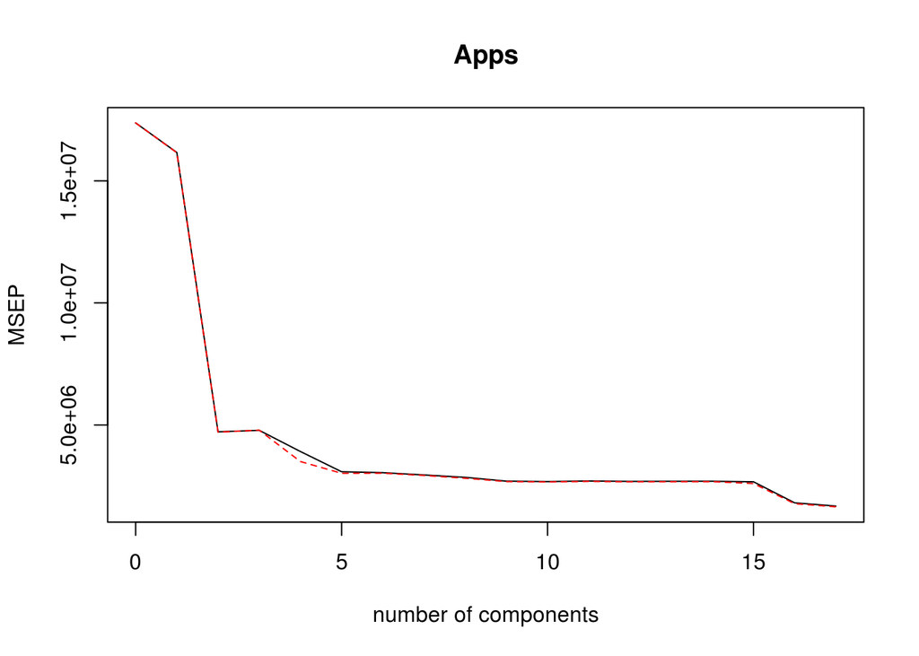

```r
pcrmodel<-pcr(Apps~.,data=train,scale=TRUE,validation="CV")

validationplot(pcrmodel,val.type="MSEP")
```

```r
predict.pcr<-predict(pcrmodel,test,ncomp=17)
mean((test$Apps-predict.pcr)^2)
```

```
## [1] 769127.1
```

We see that the cross validation error is minimum for M=17.If we use 17 components it gives a mean square error of 7.69127110^{5}.

This is close to the one for least squares method.

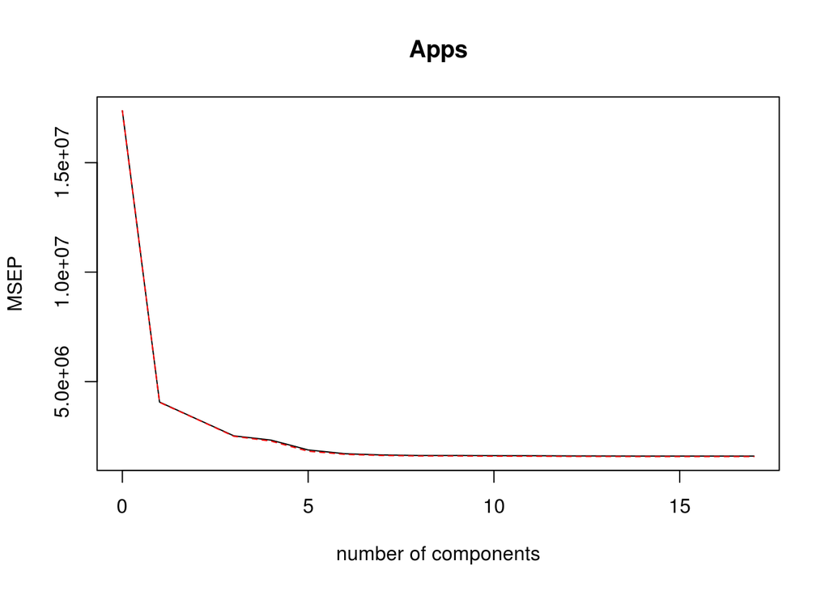

```r
plsrmodel<-plsr(Apps~.,data=train,scale=TRUE,validation="CV")

validationplot(plsrmodel,val.type="MSEP")
```

```r
predict.plsr<-predict(plsrmodel,test,ncomp=10)
mean((test$Apps-predict.plsr)^2)
```

```
## [1] 775233.6
```

We see that the cross validation error is minimum for M=10.If we use 10 components it gives a mean square error of 7.752336110^{5}.

This is higher compared to the one for least squares method.

```r
#Least Square model
test.avg <- mean(test$Apps)
lm.r2 <- 1 - mean((predicted.apps - test$Apps)^2) / mean((test.avg - test$Apps)^2)
#Ridge model
ridge.r2 <- 1 - mean((pred.newridge - test$Apps)^2) / mean((test.avg - test$Apps)^2)
#Lasso model
lasso.r2 <- 1 - mean((pred.newlasso - test$Apps)^2) / mean((test.avg - test$Apps)^2)
#PCR model
pcr.r2 <- 1 - mean((predict.pcr - test$Apps)^2) / mean((test.avg - test$Apps)^2)
#PLS model
pls.r2 <- 1 - mean((predict.plsr - test$Apps)^2) / mean((test.avg - test$Apps)^2)
```

Least Square Test R-Square: 0.918807

Ridge Model Test R-Square: 0.9188096

Lasso Model Test R-Square: 0.9188143

PCR Model Test R-Square: 0.918807

PLS Model Test R-Square: 0.9181624

It can be observed that the Lasso model predicts the highest R-Square. Though all the models give similar results.

This was expected as the minimum mean square error was found for the Lasso model across all the models.